# GEOG-503 Lab 6

## Due date:

Oct 10 (Wednesday) 11:59 pm

## What to submit:

The Jupyter Notebook that contains solutions to the following questions. File name convention for submission: **lastname_firstname_lab6.ipynb**

It must be submitted to [myCourses](https://mycourses.binghamton.edu/)

## Questions

Answer the questions or complete the tasks outlined in bold below, use the specific method described if applicable.

## Grading

- 20 for points each question.

## Data

- http://spatial.binghamton.edu/geog503/data/lab6_data.zip

# Question 1

Write a program that performs the following tasks using the **airports.shp**

# Question 1.1

- Select those airports that are located in the **Nome Census Area** county and print out their **NAME** and **LOCID**. (5 pt.)

```python
try:
    import archook #The module which locates arcgis
    archook.get_arcpy()
    import arcpy
except ImportError:
    print("import arcpy error")
```

```python
import os
arcpy.env.workspace = os.getcwd() + '/data'
fc_lst = arcpy.ListFeatureClasses()
print fc_lst
```

```
[u'airports.shp', u'alaska.shp', u'roads.shp']
```

```python
fc = fc_lst[0]
fields = arcpy.ListFields(fc)
print "Field names of" + fc + ':'
for field in fields:
    print field.name
```

```
Field names ofairports.shp:
FID
Shape
AREA
PERIMETER
AIRPRTX020
LOCID
FEATURE
NAME
TOT_ENP
STATE
COUNTY
FIPS
STATE_FIPS
SHAPE_X
SHAPE_Y
```

```python
fd_lst = ["COUNTY","NAME","LOCID"]
cursor = arcpy.da.SearchCursor(fc,fd_lst)
for row in cursor:
    if row[0] == 'Nome Census Area':
        print "COUNTY = %s      NAME = %-20s LOCID = %-20s" %(row[0],row[1],row[2])
del cursor,row
```

```
COUNTY = Nome Census Area      NAME = Koyuk                LOCID = KKA
COUNTY = Nome Census Area      NAME = Saint Michael        LOCID = 5S8
COUNTY = Nome Census Area      NAME = Stebbins             LOCID = WBB
COUNTY = Nome Census Area      NAME = Unalakleet           LOCID = UNK
COUNTY = Nome Census Area      NAME = Shaktoolik           LOCID = 38A
COUNTY = Nome Census Area      NAME = Elim                 LOCID = ELI
COUNTY = Nome Census Area      NAME = Golovin              LOCID = GLV
COUNTY = Nome Census Area      NAME = White Mountain       LOCID = WMO
COUNTY = Nome Census Area      NAME = Nome                 LOCID = OME
COUNTY = Nome Census Area      NAME = Savoonga             LOCID = SVA
COUNTY = Nome Census Area      NAME = Teller               LOCID = K54
COUNTY = Nome Census Area      NAME = Brevig Mission       LOCID = KTS
COUNTY = Nome Census Area      NAME = Shishmaref           LOCID = SHH
COUNTY = Nome Census Area      NAME = Wales                LOCID = IWK
COUNTY = Nome Census Area      NAME = Gambell              LOCID = GAM
```

## Question 1.2

- Based on the selected airports in Question 1.1, update the **STATE** field to **AK** if their STATE field is empty. (5 pt.)

```python
fd_lst = ["COUNTY","NAME","LOCID","STATE"]
cursor = arcpy.da.SearchCursor(fc,fd_lst)
for row in cursor:
    if row[0] == 'Nome Census Area':
        print "COUNTY = %s      NAME = %-20s LOCID = %-8s  STATE =% s" %(row[0],row[1],row[2],row[3])
del cursor,row
```

```
COUNTY = Nome Census Area      NAME = Koyuk                LOCID = KKA       STATE =AK
COUNTY = Nome Census Area      NAME = Saint Michael        LOCID = 5S8       STATE =
COUNTY = Nome Census Area      NAME = Stebbins             LOCID = WBB       STATE =AK
COUNTY = Nome Census Area      NAME = Unalakleet           LOCID = UNK       STATE =
COUNTY = Nome Census Area      NAME = Shaktoolik           LOCID = 38A       STATE =AK
COUNTY = Nome Census Area      NAME = Elim                 LOCID = ELI       STATE =AK
COUNTY = Nome Census Area      NAME = Golovin              LOCID = GLV       STATE =AK
COUNTY = Nome Census Area      NAME = White Mountain       LOCID = WMO       STATE =AK
COUNTY = Nome Census Area      NAME = Nome                 LOCID = OME       STATE =AK
COUNTY = Nome Census Area      NAME = Savoonga             LOCID = SVA       STATE =AK
COUNTY = Nome Census Area      NAME = Teller               LOCID = K54       STATE =AK
COUNTY = Nome Census Area      NAME = Brevig Mission       LOCID = KTS       STATE =AK
COUNTY = Nome Census Area      NAME = Shishmaref           LOCID = SHH       STATE =AK
COUNTY = Nome Census Area      NAME = Wales                LOCID = IWK       STATE =AK
COUNTY = Nome Census Area      NAME = Gambell              LOCID = GAM       STATE =AK
```

```python
fd_lst = ["COUNTY","NAME","LOCID","STATE"]
cursor = arcpy.da.UpdateCursor(fc,fd_lst)
for row in cursor:
    if row[0] == 'Nome Census Area':
        if row[3] != 'AK':
            row[3] = 'AK'
        print "COUNTY = %s      NAME = %-20s LOCID = %-8s  STATE =% s" %(row[0],row[1],row[2],row[3])
del cursor, row
```

```
COUNTY = Nome Census Area      NAME = Koyuk                LOCID = KKA       STATE =AK
COUNTY = Nome Census Area      NAME = Saint Michael        LOCID = 5S8       STATE =AK
COUNTY = Nome Census Area      NAME = Stebbins             LOCID = WBB       STATE =AK
COUNTY = Nome Census Area      NAME = Unalakleet           LOCID = UNK       STATE =AK
COUNTY = Nome Census Area      NAME = Shaktoolik           LOCID = 38A       STATE =AK
COUNTY = Nome Census Area      NAME = Elim                 LOCID = ELI       STATE =AK
COUNTY = Nome Census Area      NAME = Golovin              LOCID = GLV       STATE =AK
COUNTY = Nome Census Area      NAME = White Mountain       LOCID = WMO       STATE =AK
COUNTY = Nome Census Area      NAME = Nome                 LOCID = OME       STATE =AK
COUNTY = Nome Census Area      NAME = Savoonga             LOCID = SVA       STATE =AK
COUNTY = Nome Census Area      NAME = Teller               LOCID = K54       STATE =AK
COUNTY = Nome Census Area      NAME = Brevig Mission       LOCID = KTS       STATE =AK
COUNTY = Nome Census Area      NAME = Shishmaref           LOCID = SHH       STATE =AK
COUNTY = Nome Census Area      NAME = Wales                LOCID = IWK       STATE =AK
COUNTY = Nome Census Area      NAME = Gambell              LOCID = GAM       STATE =AK
```

# Question 1.3

- Export the information about those airports in **Nome Census Area** County to a text file, including these fields: **NAME, LOCID, Longitude, and Latitude**. (10 pt.)

```python
with open('./data/airports_NCA.txt','w') as f:
    print 'Content wirtten to the text file:'
    fd_lst = ["COUNTY","NAME","LOCID","SHAPE@X","SHAPE@Y"]
    cursor = arcpy.da.SearchCursor(fc,fd_lst)
    for row in cursor:
        if row[0] == 'Nome Census Area':
            row_new = "NAME = %-20s  LOCID = %-10s X = %-20s  Y = % s" %(row[1],row[2],row[3],row[4])
            print row_new
            f.writelines(row_new + '\n')
    del cursor, row
```

```
Content wirtten to the text file:
NAME = Koyuk                 LOCID = KKA        X = -161.151077271        Y = 64.9380722046
NAME = Saint Michael         LOCID = 5S8        X = -162.110366821        Y = 63.4900512695
NAME = Stebbins              LOCID = WBB        X = -162.282745361        Y = 63.5159187317
NAME = Unalakleet            LOCID = UNK        X = -160.798950195        Y = 63.8883590698
NAME = Shaktoolik            LOCID = 38A        X = -161.202529907        Y = 64.3626327515
NAME = Elim                  LOCID = ELI        X = -162.270065308        Y = 64.6140060425
NAME = Golovin               LOCID = GLV        X = -163.039520264        Y = 64.5434341431
NAME = White Mountain        LOCID = WMO        X = -163.41255188         Y = 64.6891937256
NAME = Nome                  LOCID = OME        X = -165.445251465        Y = 64.5121994019
NAME = Savoonga              LOCID = SVA        X = -170.492630005        Y = 63.6863937378
NAME = Teller                LOCID = K54        X = -166.336013794        Y = 65.2408981323
NAME = Brevig Mission        LOCID = KTS        X = -166.463165283        Y = 65.3313598633
NAME = Shishmaref            LOCID = SHH        X = -166.089553833        Y = 66.2495651245
NAME = Wales                 LOCID = IWK        X = -168.09916687         Y = 65.6239395142
NAME = Gambell               LOCID = GAM        X = -171.732818604        Y = 63.7667655945
```

```python
# with open('./data/airports.txt') as f:
#     line = f.readline()
#     while line:
# #         print f.readline()
#         row = list(line.split(','))
#         line = f.readline()
#         print row
```

# Question 2

Write a program that converts the **airports.txt** (lab6_data/airport.txt) into a Point-type shapefile. The resulting shapefile should have the following fields based on the information from the airports.txt, including **NAME, LOCID, X, and Y.** (20 pt.)

```python
arcpy.env.overwriteOutput = True
out_path = arcpy.env.workspace + '/Results'
fileds = ["NAME","LOCID","SHAPE@X","SHAPE@Y"]
try:
    arcpy.CreateFeatureclass_management(out_path,'airports.shp',geometry_type = "POINT")
    print 'Creating output feature class: ' + out_path + '/airports.shp'
    print 'Adding fields to the feature class ...'
    for filed in fileds:
        arcpy.AddField_management(out_path + '/airports.shp',filed,"String")
    fields_fc = arcpy.ListFields(out_path + '/airports.shp')
    for field in fields_fc:
        print field.name
    print 'Successful add fields.'
    cursor = arcpy.da.InsertCursor(out_path + '/airports.shp',fileds)
    with open('./data/airports.txt') as f:
        line = f.readline()
        while line:
            row1 = list(line.split(','))
            cursor.insertRow([row1[1].split(':')[1],row1[2].split(':')[1],row1[3].split(':')[1],row1[4].split(':')[1]])
            line = f.readline()
    print 'Successful add field'
except:
    print 'Something Wrong!'
del cursor
```

```
Creating output feature class: H:\G560\Lab6/data/Results/airports.shp
Adding fields to the feature class ...
FID
Shape
Id
NAME
LOCID
SHAPE_X
SHAPE_Y
Successful add fields.
Successful add field
```

```python
cursor = arcpy.da.SearchCursor(out_path + '/airports.shp',fileds)
for index,row in enumerate(cursor):
    row_new = "NAME = %-20s  LOCID = %-10s X = %-20s  Y = % s" %(row[0],row[1],row[2],row[3])
    print row_new
    if index == 10:
        break
```

```
NAME =  Hyder                LOCID =  4Z7       X = -130.012527           Y = 55.904339
NAME =  Chignik Lagoon       LOCID =  KCL       X = -158.532562           Y = 56.307869
NAME =  Koyuk                LOCID =  KKA       X = -161.151077           Y = 64.938072
NAME =  Kivalina             LOCID =  KVL       X = -164.525589           Y = 67.745209
NAME =  Ketchikan Harbor     LOCID =  5KE       X = -131.685104           Y = 55.347809
NAME =  Metlakatla           LOCID =  MTM       X = -131.578064           Y = 55.131046
NAME =  Waterfall            LOCID =  KWF       X = -133.243332           Y = 55.296322
NAME =  Ketchikan            LOCID =  KTN       X = -131.713745           Y = 55.355568
NAME =  Kasaan               LOCID =  KXA       X = -132.397522           Y = 55.537415
NAME =  Hollis               LOCID =  HYL       X = -132.646088           Y = 55.481586
NAME =  Craig                LOCID =  CGA       X = -133.147797           Y = 55.478832
```

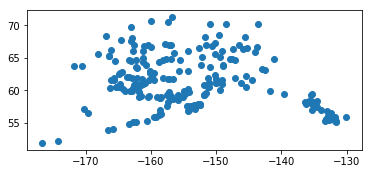

```python
import geopandas as gpd
airports  = gpd.read_file(out_path + '/airports.shp')
%matplotlib inline
airports.plot()
```